# Interactions Between Individuals in an Animal Community

Rui Ma

10/23/2017

First , we imported $allnames$ & $focalnames$ as data frames and $interactions$ as a tibble, and we would not let characters in $allnames$ be converted to factors. Additiaonlly, we pulled the column $toward$ in $interactions$ out and made a separate copy of it ($correct$) so We could perform data cleaning on it.

```r
library(dplyr)
library(tibble)
library(tidyr)
library(stringdist)
library(stringr)
library(ggplot2)
# import data
allnames = read.csv("all_names.csv", header = FALSE) # df
focalnames = read.csv("focal_names.csv", header = FALSE) # df
interactions = as_tibble(read.csv("interactions.csv"))
# don't let characters in allnames be converted to factors
allnames = data.frame(lapply(allnames, as.character), stringsAsFactors=FALSE)
corrects = tolower(interactions$toward)    # made a copy of the col toward
```

```r
cleaning = function(x) {
  x = gsub("\\?", "NA", x)   # replace ? with NA
  x = gsub(" ", "", x)       # get rid of spaces
  if (x == "") {  # replace blank row with NA
    x = "NA"
  }
  x = gsub(",", " ", x)      # replace comma with space
  x = str_trim(x, side = "right")
}
# clean up correct and correct misspelled names with amatch()
for (i in 1:length(corrects)) {
  # apply cleaning to each row of corrects and get the single names
  corrects[i]=str_split(cleaning(corrects[i]), " ")
  for (j in 1:length(corrects[[i]])) {
    if (corrects[[i]][j] != "NA") {    # skip NA's and compare the rest
      corrects[[i]][j] = allnames[(amatch(corrects[[i]][j],
                    tolower(allnames[1:length(allnames[,1]),]), maxDist = 5)),]
    }
  }
}
```

we would then reformat the data frame, get rid of the rows with NA’s, and count the frequencies of each interaction type with each focal names (see comments for detail). Note that the table $all_interactions$ contains all the unique interactions and there are 22,784 of them.

```r
# interactions with correct spellings and unnested
all_interactions = interactions %>%
  mutate(toward = corrects) %>%    # change toward to the correct version
  unnest(toward) %>%  # makes each element of its own row
  group_by(focal, behavior_cat) %>%
  arrange(focal, behavior_cat) %>%
  filter(toward != "NA")     # get rid of NA's since they don't belong

# count and transform to wide, didn't combine with ^, check unique interactions
interactions_count = all_interactions %>%
  group_by(focal, behavior_cat,toward) %>%
  tally() %>%    # count the freq of each interaction type with each focal
  spread(toward, n)    # essentially make it wide

interactions_count[is.na(interactions_count)] = 0  # replace NA's with 0
print(head(interactions_count))
```

```
## # A tibble: 6 x 201
## # Groups:   focal, behavior_cat [6]
##    focal behavior_cat Abiel  Acob Adriana Adrick Ahlam Akbar Alani Alayne
##   <fctr>       <fctr> <dbl> <dbl>   <dbl>  <dbl> <dbl> <dbl> <dbl>  <dbl>
## 1   Amen   aggression     0     0       1      1     0     0     1      1
## 2   Amen     approach     1     2       2      0     3     1     2      1
## 3   Amen        carry     0     0       0      0     2     1     1      0
## 4   Amen        groom     0     0       2      0     0     0     3      0
## 5   Amen         mate     2     0       1      0     1     1     0      0
## 6   Amen         play     0     0       5      0     2     1     4      0
## # ... with 191 more variables: Alita <dbl>, Alma <dbl>, Almon <dbl>,
## #   Anarosa <dbl>, Angelito <dbl>, Anthonio <dbl>, Antoni <dbl>,
## #   Arcadio <dbl>, Armin <dbl>, Aron <dbl>, Autumn <dbl>, Bayla <dbl>,
## #   Branden <dbl>, Breanna <dbl>, Brinna <dbl>, Bruce <dbl>, Byron <dbl>,
## #   Cacey <dbl>, Camden <dbl>, Camillia <dbl>, Carmin <dbl>,
## #   Carolyne <dbl>, Casina <dbl>, Cederick <dbl>, Chace <dbl>,
## #   Charles <dbl>, Cherissa <dbl>, Chidinma <dbl>, Christal <dbl>,
## #   Christle <dbl>, Christpher <dbl>, Cipriano <dbl>, Claire <dbl>,
## #   Colene <dbl>, Coral <dbl>, Cornell <dbl>, Correy <dbl>, Corynn <dbl>,
## #   Czarina <dbl>, Danell <dbl>, Daved <dbl>, Davisha <dbl>,
## #   Deanthony <dbl>, Dearl <dbl>, Deaven <dbl>, Desiderio <dbl>,
## #   Desieree <dbl>, Desirre <dbl>, Diandra <dbl>, Dimitrius <dbl>,
## #   Domini <dbl>, Dominigue <dbl>, Donta <dbl>, Dontray <dbl>,
## #   Ebelin <dbl>, Elayne <dbl>, Eliah <dbl>, Emilly <dbl>, Emre <dbl>,
## #   Eytan <dbl>, Fareed <dbl>, Farris <dbl>, Iban <dbl>, Idella <dbl>,
## #   Inocente <dbl>, Iona <dbl>, Jamail <dbl>, Jamari <dbl>,
## #   Janeisha <dbl>, Jarrard <dbl>, Jenel <dbl>, Jenessa <dbl>,
## #   Jermyn <dbl>, Jess <dbl>, Jolisa <dbl>, Jonquil <dbl>, Jose <dbl>,
## #   Jp <dbl>, Juanjose <dbl>, Justen <dbl>, Kade <dbl>, Kailyn <dbl>,
## #   Kameelah <dbl>, Kandance <dbl>, Kaprice <dbl>, Kaseem <dbl>,
## #   Kathe <dbl>, Kaylor <dbl>, Kendel <dbl>, Kennieth <dbl>,
## #   Keshauna <dbl>, Kesley <dbl>, Kha <dbl>, Kla <dbl>, Lacy <dbl>,
## #   Ladasha <dbl>, Laquinton <dbl>, Lashunda <dbl>, Latysha <dbl>,
## #   Lavena <dbl>, ...
```

Here for each interaction type, we would compute the pair-wise canberra distances measuring the similarity between pairs of focal animals.

```r
# pairwise canberra distances measuring the similarity between pairs of animals
behavior_distance = function(df, behavior='aggression'){
    df = df %>% filter(behavior_cat == behavior)
    mat = as.matrix(df %>% select(-focal, -behavior_cat))
    rownames(mat) = df$focal
    dist(mat, method ='canberra')
}
dist_mats = lapply(unique(interactions_count$behavior_cat),
                   behavior_distance, df = interactions_count)
attr(dist_mats,'names') = unique(as.character(interactions_count$behavior_cat))
```

Here we would use $cmdscale()$ to find a two-dimensional embedding of the pairwise distances. We would also use the MDS coordinates to produce plots showing the relations among animals for each interaction type.

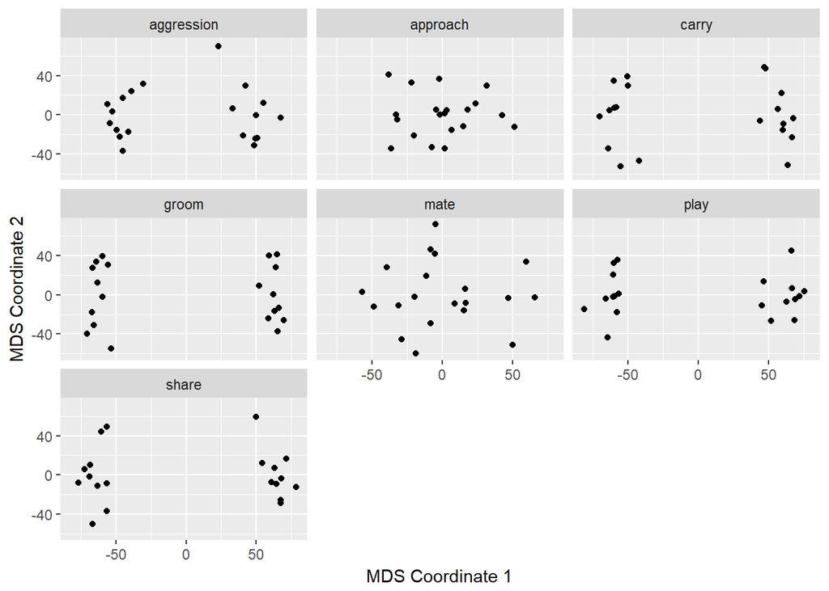

```r
# two-dimensional embedding of the pairwise distances
dist_MDS = lapply(dist_mats, cmdscale)

# Convert each set to a tibble and join with bind_rows
make_tibble = function(i){
    as.tibble(dist_MDS[[i]]) %>%
        mutate(names=rownames(dist_MDS[[i]]),
               behavior=names(dist_MDS)[[i]]) %>%
        select(behavior, names, V1, V2)
}
mds = bind_rows(lapply(1:length(dist_MDS), make_tibble))

# plots showing the relations among animals for each interaction type
mds %>%
    ggplot(aes(x=V1, y=V2)) +
    facet_wrap(~behavior) +
    geom_point() +
    ylab('MDS Coordinate 2') + xlab('MDS Coordinate 1')
```